# ledgr and its peers

Native results, research time and memory

**Note**

**Preliminary peer-suite evidence.** Only lanes present in this explicit record have measured results. Portfolio, PIT, authoring and later release- generation work remain visible in the required-assignment counts. This artifact supports internal review; external performance claims require acceptance of the complete suite.

## Warm research time

500 instruments, 1,260 daily bars, the same SMA5/10 transition rule. Each point is a median; the line shows the minimum and maximum. The label shows the number of completed repeats; all attempts remain in the record. The axis is logarithmic; open circles mark reduced-output sweeps.

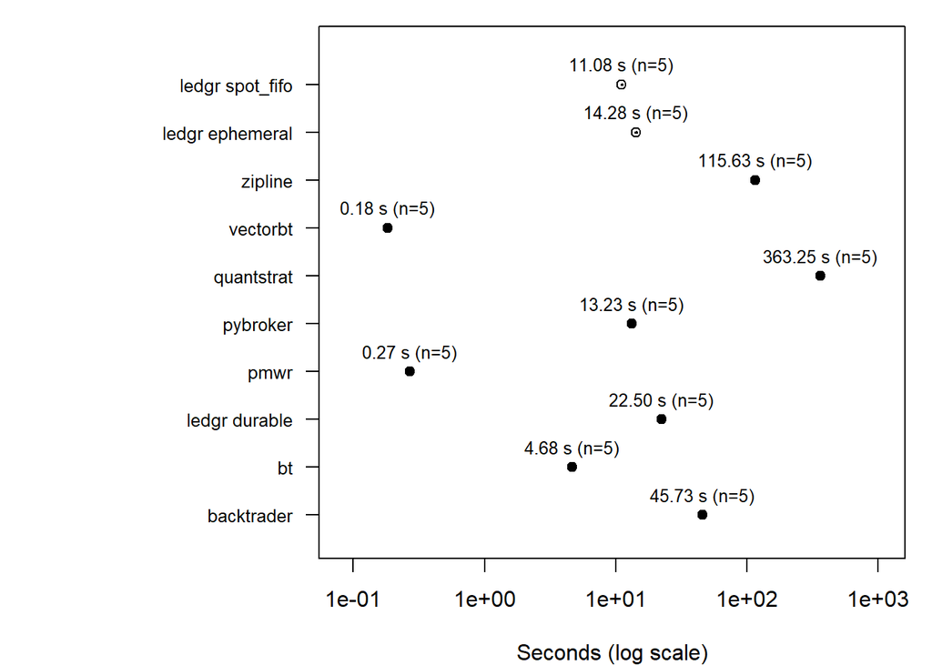

Durable ledgr and the seven quantitative peers materialize fills, cash, equity and full asset holdings. **Canonical ephemeral and spot-FIFO sweeps retain equity and closed-trade P&L.** Their absolute times describe those public workflows; they have no full-output peer speed ratio. Warm means a fresh independent book on already prepared native input, with indicator calculation included.

## Do the results agree?

Every run opens flat with USD10,000,000 cash and targets zero or one share per asset. Dollar differences below describe this synthetic rule, including its idle cash; they are not return forecasts or a percentage tolerance. “Same decisions only” and “same trades and balances” are disjoint labels.

USD differences from ledgr; ledgr’s rule profit: 728506.71

| engine | agreement | final_equity_difference | max_equity_difference |
| --- | --- | --- | --- |
| backtrader | same trades and balances | 0.000000e+00 | 0.000000e+00 |
| bt | same decisions only | -5.108017e+02 | 1.965282e+03 |
| pmwr | same decisions only | -2.200000e-07 | 3.200000e-07 |
| pybroker | same decisions only | -2.100000e-07 | 3.300000e-07 |
| quantstrat | same trades and balances | -2.100000e-07 | 3.300000e-07 |
| vectorbt | same trades and balances | -2.200000e-07 | 3.200000e-07 |
| zipline | classified residual | -1.053889e+04 | 1.929972e+04 |

The maintained PMwR/vectorbt pair also checks portfolio state exactly, without a numeric tolerance. Reported prices have their own field:

|  | cash_exact | equity_exact | holdings_exact | decisions_exact | reported_prices_exact |
| --- | --- | --- | --- | --- | --- |
| 500x1260 | TRUE | TRUE | TRUE | TRUE | FALSE |

PMwR’s wealth path and its reported journal prices are checked separately. Its pinned journal reports closing prices in this open-execution recipe. PyBroker’s native within-bar fill order differs; bt uses current-close execution; Zipline’s native daily execution uses the following session’s close, and daily-bundle price precision also changes scores and some decisions. These observations remain classified, with no adapter-generated fills, shifted targets or widened numeric bounds.

Only fully qualified full-output rows with five valid repeats enter the following ratio, when eligible rows exist. With fewer repeats, no ratio is reported. A value above one means that peer took longer than durable ledgr on this workload. It is not a universal engine ranking.

|  | peer | peer_time_over_ledgr |
| --- | --- | --- |
| quantstrat | quantstrat | 16.1444 |
| backtrader | backtrader | 2.0326 |
| vectorbt | vectorbt | 0.0082 |

## Scaling: instruments and pulses

The daily shapes vary breadth and length. The20x23400 shape uses60 synthetic sessions of390 minute-end labels; this tests many pulses, not exchange-calendar or production intraday support. Values below are warm seconds, with actual repeat count, median and range. Missing peers were not assigned to that shape. The same named native output differences continue to govern agreement. PMwR and vectorbt run in later paired windows: first position alternates across ordinary repeats. Other frameworks retain their original windows. Actual source, ordering and host observations remain recorded. Historical PMwR clocks are preserved separately and never pooled with the new pairs.

|  | shape | engine | workflow | n | median | min | max |
| --- | --- | --- | --- | --- | --- | --- | --- |
| 55 | 10x7200 | backtrader | durable | 5 | 5.50 | 5.34 | 5.51 |
| 56 | 10x7200 | ledgr | durable | 5 | 10.68 | 10.51 | 10.78 |
| 57 | 10x7200 | pmwr | durable | 5 | 0.14 | 0.12 | 0.14 |
| 58 | 10x7200 | vectorbt | durable | 5 | 0.08 | 0.08 | 0.08 |
| 59 | 10x7200 | ledgr | ephemeral | 5 | 8.85 | 8.64 | 8.87 |
| 60 | 10x7200 | ledgr | spot_fifo | 5 | 10.23 | 10.11 | 10.36 |
| 61 | 1166x252 | ledgr | durable | 5 | 11.31 | 11.15 | 11.34 |
| 62 | 1166x252 | pmwr | durable | 5 | 0.27 | 0.26 | 0.28 |
| 63 | 1166x252 | pybroker | durable | 5 | 6.33 | 6.26 | 6.42 |
| 64 | 1166x252 | vectorbt | durable | 5 | 0.14 | 0.13 | 0.14 |
| 65 | 1166x252 | ledgr | ephemeral | 5 | 5.81 | 5.79 | 5.85 |
| 66 | 1166x252 | ledgr | spot_fifo | 5 | 3.89 | 3.85 | 3.92 |
| 92 | 20x23400 | backtrader | durable | 5 | 33.97 | 33.80 | 35.00 |
| 93 | 20x23400 | ledgr | durable | 5 | 45.81 | 44.71 | 47.75 |
| 94 | 20x23400 | pmwr | durable | 5 | 0.57 | 0.56 | 0.61 |
| 95 | 20x23400 | pybroker | durable | 5 | 10.72 | 10.63 | 10.92 |
| 96 | 20x23400 | vectorbt | durable | 5 | 0.25 | 0.25 | 0.26 |
| 97 | 20x23400 | ledgr | ephemeral | 5 | 40.47 | 40.15 | 41.10 |
| 98 | 20x23400 | ledgr | spot_fifo | 5 | 60.11 | 59.47 | 60.64 |

## Large stress case

1166 instruments x7200 bars. One descriptive observation per workflow; **no precise ranking or speed ratio**. The cap is120 minutes or16 GiB of sampled tree private bytes. Censored outcomes remain visible below.

|  | engine | workflow | n | median | min | max |
| --- | --- | --- | --- | --- | --- | --- |
| 67 | backtrader | durable | 1 | 655.45 | 655.45 | 655.45 |
| 68 | ledgr | durable | 1 | 386.64 | 386.64 | 386.64 |
| 69 | pmwr | durable | 1 | 3.40 | 3.40 | 3.40 |
| 70 | pybroker | durable | 1 | 191.57 | 191.57 | 191.57 |
| 71 | vectorbt | durable | 1 | 2.33 | 2.33 | 2.33 |
| 72 | ledgr | ephemeral | 1 | 204.47 | 204.47 | 204.47 |
| 73 | ledgr | spot_fifo | 1 | 221.91 | 221.91 | 221.91 |

**Repeated research sessions: actual batches and completion counts**

Each N is the number of fresh experiments **per arm**, on the same12x90 prepared input. Cold includes preparation plus N independent books; warm runs another N independent books. These are measured batch totals, never projections from one run. Each book recalculates signals and materializes its workflow’s required outputs. Sweeps are repeated one-candidate calls, not one N-candidate grid call. Books are retained through the batch for untimed exact financial reset checks; only prepared input is reused between arms. Per-book progress recording and identity checks are inside the batch clock. A resource-censored batch reports actual returned-book counts, not requested counts as completions; any captured partial clocks stay excluded from medians.

The maintainer curtailed the remaining ledgr N1000 repeats. Completed observations remain in the tables; operator-unrun rows identify that decision. They are not engine failures or resource-limit claims. Other assigned peers completed their planned session repeats.

|  | shape | engine | workflow | n | median | min | max |
| --- | --- | --- | --- | --- | --- | --- | --- |
| 74 | 12x90_N10 | ledgr | durable | 5 | 5.37 | 5.28 | 5.45 |
| 75 | 12x90_N10 | pmwr | durable | 5 | 0.06 | 0.05 | 0.07 |
| 76 | 12x90_N10 | pybroker | durable | 5 | 0.36 | 0.34 | 0.37 |
| 77 | 12x90_N10 | vectorbt | durable | 5 | 0.24 | 0.23 | 0.24 |
| 78 | 12x90_N10 | ledgr | ephemeral | 5 | 2.86 | 2.84 | 2.92 |
| 79 | 12x90_N10 | ledgr | spot_fifo | 5 | 3.00 | 3.00 | 3.09 |
| 80 | 12x90_N100 | ledgr | durable | 5 | 53.86 | 53.28 | 54.42 |
| 81 | 12x90_N100 | pmwr | durable | 5 | 0.50 | 0.48 | 0.50 |
| 82 | 12x90_N100 | pybroker | durable | 5 | 3.57 | 3.51 | 3.60 |
| 83 | 12x90_N100 | vectorbt | durable | 5 | 2.43 | 2.36 | 2.44 |
| 84 | 12x90_N100 | ledgr | ephemeral | 5 | 29.78 | 29.06 | 29.88 |
| 85 | 12x90_N100 | ledgr | spot_fifo | 5 | 30.89 | 30.27 | 31.11 |
| 86 | 12x90_N1000 | ledgr | durable | 3 | 621.08 | 620.73 | 640.52 |
| 87 | 12x90_N1000 | pmwr | durable | 5 | 5.15 | 4.97 | 5.18 |
| 88 | 12x90_N1000 | pybroker | durable | 5 | 35.75 | 35.03 | 35.94 |
| 89 | 12x90_N1000 | vectorbt | durable | 5 | 24.78 | 23.95 | 25.08 |
| 90 | 12x90_N1000 | ledgr | ephemeral | 2 | 319.97 | 319.97 | 319.97 |
| 91 | 12x90_N1000 | ledgr | spot_fifo | 3 | 338.06 | 326.37 | 347.14 |

|  | shape | engine | workflow | repetition | status | requested | completed_cold | completed_warm | elapsed_sec |
| --- | --- | --- | --- | --- | --- | --- | --- | --- | --- |
| 112 | 12x90_N10 | ledgr | durable | 1 | complete | 10 | 10 | 10 | 13.17 |
| 212 | 12x90_N10 | ledgr | ephemeral | 1 | complete | 10 | 10 | 10 | 7.90 |
| 312 | 12x90_N10 | ledgr | spot_fifo | 1 | complete | 10 | 10 | 10 | 8.00 |
| 412 | 12x90_N10 | ledgr | durable | 2 | complete | 10 | 10 | 10 | 12.82 |
| 511 | 12x90_N10 | ledgr | spot_fifo | 2 | complete | 10 | 10 | 10 | 7.96 |
| 612 | 12x90_N10 | ledgr | ephemeral | 2 | complete | 10 | 10 | 10 | 7.69 |
| 712 | 12x90_N10 | ledgr | spot_fifo | 3 | complete | 10 | 10 | 10 | 7.93 |
| 812 | 12x90_N10 | ledgr | durable | 3 | complete | 10 | 10 | 10 | 13.20 |
| 912 | 12x90_N10 | ledgr | ephemeral | 3 | complete | 10 | 10 | 10 | 7.70 |
| 104 | 12x90_N10 | ledgr | spot_fifo | 4 | complete | 10 | 10 | 10 | 7.95 |
| 113 | 12x90_N10 | ledgr | ephemeral | 4 | complete | 10 | 10 | 10 | 7.69 |
| 122 | 12x90_N10 | ledgr | durable | 4 | complete | 10 | 10 | 10 | 13.28 |
| 132 | 12x90_N10 | ledgr | ephemeral | 5 | complete | 10 | 10 | 10 | 7.70 |
| 142 | 12x90_N10 | ledgr | spot_fifo | 5 | complete | 10 | 10 | 10 | 7.95 |
| 152 | 12x90_N10 | ledgr | durable | 5 | complete | 10 | 10 | 10 | 12.80 |
| 162 | 12x90_N100 | ledgr | durable | 1 | complete | 100 | 100 | 100 | 108.71 |
| 172 | 12x90_N100 | ledgr | ephemeral | 1 | complete | 100 | 100 | 100 | 59.65 |
| 182 | 12x90_N100 | ledgr | spot_fifo | 1 | complete | 100 | 100 | 100 | 63.30 |
| 192 | 12x90_N100 | ledgr | durable | 2 | complete | 100 | 100 | 100 | 109.24 |
| 202 | 12x90_N100 | ledgr | spot_fifo | 2 | complete | 100 | 100 | 100 | 63.38 |
| 213 | 12x90_N100 | ledgr | ephemeral | 2 | complete | 100 | 100 | 100 | 59.60 |
| 222 | 12x90_N100 | ledgr | spot_fifo | 3 | complete | 100 | 100 | 100 | 63.55 |
| 232 | 12x90_N100 | ledgr | durable | 3 | complete | 100 | 100 | 100 | 110.08 |
| 242 | 12x90_N100 | ledgr | ephemeral | 3 | complete | 100 | 100 | 100 | 61.12 |
| 252 | 12x90_N100 | ledgr | spot_fifo | 4 | complete | 100 | 100 | 100 | 64.25 |
| 262 | 12x90_N100 | ledgr | ephemeral | 4 | complete | 100 | 100 | 100 | 60.28 |
| 272 | 12x90_N100 | ledgr | durable | 4 | complete | 100 | 100 | 100 | 109.05 |
| 282 | 12x90_N100 | ledgr | ephemeral | 5 | complete | 100 | 100 | 100 | 60.52 |
| 292 | 12x90_N100 | ledgr | spot_fifo | 5 | complete | 100 | 100 | 100 | 62.70 |
| 302 | 12x90_N100 | ledgr | durable | 5 | complete | 100 | 100 | 100 | 110.47 |

[output cut: 60 more lines]

**Warm memory across scaling, stress and sessions**

Warm-phase sampled process-tree private and working-set peaks in GiB, grouped by shape, workflow and completion status. Censored-phase samples are retained separately; they are lower bounds for an unfinished workload. A process that never reaches warm has no warm sample. Preparation, cold and export samples remain in the record. Output retention and tracing affect memory, so these are workflow observations, not intrinsic engine limits.

| shape | engine | workflow | status | private.n | private.median_GiB | private.min_GiB | private.max_GiB | working_set.n | working_set.median_GiB | working_set.min_GiB | working_set.max_GiB | observation |
| --- | --- | --- | --- | --- | --- | --- | --- | --- | --- | --- | --- | --- |
| 10x7200 | backtrader | durable | complete | 5 | 0.139 | 0.135 | 0.140 | 5 | 0.166 | 0.163 | 0.168 | sampled lower bound |
| 10x7200 | ledgr | durable | complete | 5 | 0.374 | 0.358 | 0.391 | 5 | 0.354 | 0.341 | 0.374 | sampled lower bound |
| 10x7200 | ledgr | ephemeral | complete | 5 | 0.334 | 0.323 | 0.336 | 5 | 0.331 | 0.319 | 0.334 | sampled lower bound |
| 10x7200 | ledgr | spot_fifo | complete | 5 | 0.354 | 0.350 | 0.360 | 5 | 0.353 | 0.348 | 0.358 | sampled lower bound |
| 10x7200 | pmwr | durable | complete | NA | NA | NA | NA | NA | NA | NA | NA | no warm sample; see status |
| 10x7200 | vectorbt | durable | complete | NA | NA | NA | NA | NA | NA | NA | NA | no warm sample; see status |
| 1166x252 | ledgr | durable | complete | 5 | 0.512 | 0.495 | 0.534 | 5 | 0.511 | 0.494 | 0.532 | sampled lower bound |
| 1166x252 | ledgr | ephemeral | complete | 5 | 0.492 | 0.447 | 0.493 | 5 | 0.490 | 0.442 | 0.490 | sampled lower bound |
| 1166x252 | ledgr | spot_fifo | complete | 5 | 0.464 | 0.458 | 0.465 | 5 | 0.461 | 0.456 | 0.462 | sampled lower bound |
| 1166x252 | pmwr | durable | complete | 1 | 0.346 | 0.346 | 0.346 | 1 | 0.328 | 0.328 | 0.328 | sampled lower bound |
| 1166x252 | pybroker | durable | complete | 5 | 0.438 | 0.433 | 0.439 | 5 | 0.461 | 0.456 | 0.463 | sampled lower bound |
| 1166x252 | vectorbt | durable | complete | 4 | 0.322 | 0.320 | 0.323 | 4 | 0.372 | 0.371 | 0.374 | sampled lower bound |
| 1166x7200 | backtrader | durable | complete | 1 | 7.744 | 7.744 | 7.744 | 1 | 7.702 | 7.702 | 7.702 | sampled lower bound |
| 1166x7200 | ledgr | durable | complete | 1 | 3.719 | 3.719 | 3.719 | 1 | 3.674 | 3.674 | 3.674 | sampled lower bound |
| 1166x7200 | ledgr | ephemeral | complete | 1 | 3.987 | 3.987 | 3.987 | 1 | 3.961 | 3.961 | 3.961 | sampled lower bound |
| 1166x7200 | ledgr | spot_fifo | complete | 1 | 4.625 | 4.625 | 4.625 | 1 | 4.606 | 4.606 | 4.606 | sampled lower bound |
| 1166x7200 | pmwr | durable | complete | 1 | 6.265 | 6.265 | 6.265 | 1 | 6.154 | 6.154 | 6.154 | sampled lower bound |
| 1166x7200 | pybroker | durable | complete | 1 | 8.445 | 8.445 | 8.445 | 1 | 8.447 | 8.447 | 8.447 | sampled lower bound |
| 1166x7200 | vectorbt | durable | complete | 1 | 2.101 | 2.101 | 2.101 | 1 | 1.769 | 1.769 | 1.769 | sampled lower bound |
| 12x90_N10 | ledgr | durable | complete | 5 | 0.366 | 0.365 | 0.368 | 5 | 0.316 | 0.314 | 0.316 | sampled lower bound |
| 12x90_N10 | ledgr | ephemeral | complete | 5 | 0.283 | 0.283 | 0.283 | 5 | 0.278 | 0.277 | 0.278 | sampled lower bound |
| 12x90_N10 | ledgr | spot_fifo | complete | 5 | 0.298 | 0.297 | 0.300 | 5 | 0.294 | 0.293 | 0.296 | sampled lower bound |
| 12x90_N10 | pmwr | durable | complete | NA | NA | NA | NA | NA | NA | NA | NA | no warm sample; see status |
| 12x90_N10 | pybroker | durable | complete | 5 | 0.164 | 0.163 | 0.165 | 5 | 0.188 | 0.187 | 0.189 | sampled lower bound |
| 12x90_N10 | vectorbt | durable | complete | 5 | 0.257 | 0.256 | 0.258 | 5 | 0.321 | 0.320 | 0.322 | sampled lower bound |
| 12x90_N100 | ledgr | durable | complete | 5 | 0.400 | 0.396 | 0.402 | 5 | 0.345 | 0.341 | 0.351 | sampled lower bound |
| 12x90_N100 | ledgr | ephemeral | complete | 5 | 0.288 | 0.286 | 0.309 | 5 | 0.283 | 0.282 | 0.304 | sampled lower bound |
| 12x90_N100 | ledgr | spot_fifo | complete | 5 | 0.302 | 0.302 | 0.303 | 5 | 0.298 | 0.297 | 0.298 | sampled lower bound |
| 12x90_N100 | pmwr | durable | complete | 5 | 0.125 | 0.125 | 0.126 | 5 | 0.109 | 0.109 | 0.109 | sampled lower bound |
| 12x90_N100 | pybroker | durable | complete | 5 | 0.167 | 0.167 | 0.167 | 5 | 0.191 | 0.191 | 0.192 | sampled lower bound |
| 12x90_N100 | vectorbt | durable | complete | 5 | 0.265 | 0.263 | 0.266 | 5 | 0.327 | 0.325 | 0.329 | sampled lower bound |
| 12x90_N1000 | ledgr | durable | complete | 3 | 0.479 | 0.477 | 0.481 | 3 | 0.431 | 0.428 | 0.434 | sampled lower bound |
| 12x90_N1000 | ledgr | durable | unrun_after_executor_requested_stop | NA | NA | NA | NA | NA | NA | NA | NA | no warm sample; see status |
| 12x90_N1000 | ledgr | ephemeral | complete | 2 | 0.361 | 0.360 | 0.361 | 2 | 0.356 | 0.356 | 0.357 | sampled lower bound |
| 12x90_N1000 | ledgr | ephemeral | unrun_after_executor_requested_stop | NA | NA | NA | NA | NA | NA | NA | NA | no warm sample; see status |
| 12x90_N1000 | ledgr | spot_fifo | complete | 3 | 0.374 | 0.372 | 0.376 | 3 | 0.369 | 0.369 | 0.372 | sampled lower bound |
| 12x90_N1000 | ledgr | spot_fifo | unrun_after_executor_requested_stop | NA | NA | NA | NA | NA | NA | NA | NA | no warm sample; see status |
| 12x90_N1000 | pmwr | durable | complete | 5 | 0.138 | 0.137 | 0.141 | 5 | 0.121 | 0.120 | 0.124 | sampled lower bound |
| 12x90_N1000 | pybroker | durable | complete | 5 | 0.194 | 0.194 | 0.195 | 5 | 0.219 | 0.218 | 0.219 | sampled lower bound |
| 12x90_N1000 | vectorbt | durable | complete | 5 | 0.297 | 0.297 | 0.297 | 5 | 0.358 | 0.357 | 0.358 | sampled lower bound |
| 20x23400 | backtrader | durable | complete | 5 | 0.517 | 0.505 | 0.518 | 5 | 0.543 | 0.531 | 0.545 | sampled lower bound |
| 20x23400 | ledgr | durable | complete | 5 | 0.627 | 0.576 | 0.644 | 5 | 0.609 | 0.561 | 0.620 | sampled lower bound |
| 20x23400 | ledgr | ephemeral | complete | 5 | 0.558 | 0.554 | 0.567 | 5 | 0.556 | 0.551 | 0.566 | sampled lower bound |
| 20x23400 | ledgr | spot_fifo | complete | 5 | 0.676 | 0.652 | 0.677 | 5 | 0.674 | 0.649 | 0.675 | sampled lower bound |
| 20x23400 | pmwr | durable | complete | 5 | 0.340 | 0.289 | 0.476 | 5 | 0.323 | 0.272 | 0.459 | sampled lower bound |
| 20x23400 | pybroker | durable | complete | 5 | 0.659 | 0.654 | 0.661 | 5 | 0.682 | 0.679 | 0.685 | sampled lower bound |
| 20x23400 | vectorbt | durable | complete | 5 | 0.358 | 0.357 | 0.360 | 5 | 0.401 | 0.400 | 0.402 | sampled lower bound |

## Coverage so far

Record 20261031-ws5-observed - 2026-10-31 - product 891c23c8

| engine | required | executed | trade_balance_agreement | decision_only_agreement | classified_residual | not_run |
| --- | --- | --- | --- | --- | --- | --- |
| ledgr | 36 | 27 | 0 | 0 | 0 | 9 |
| quantstrat | 9 | 2 | 2 | 0 | 0 | 7 |
| pmwr | 16 | 9 | 0 | 9 | 0 | 7 |
| backtrader | 12 | 5 | 5 | 0 | 0 | 7 |
| bt | 9 | 2 | 0 | 2 | 0 | 7 |
| zipline | 9 | 2 | 0 | 0 | 2 | 7 |
| pybroker | 16 | 8 | 0 | 8 | 0 | 8 |
| vectorbt | 9 | 9 | 9 | 0 | 0 | 0 |

## Memory during the warm run

The table shows private-byte peaks (median, range) and median working-set peaks in MiB. The count is the number of runs whose warm phase was sampled. A short phase can fall between samples; missing observations are not zero memory. Working-set sums include shared pages and do not measure unique physical memory.

| engine | workflow | sampled_runs | median_MiB | min_MiB | max_MiB | working_set_MiB |
| --- | --- | --- | --- | --- | --- | --- |
| backtrader | durable | 5 | 691.2 | 674.1 | 692.6 | 712.9 |
| bt | durable | 5 | 379.2 | 377.6 | 380.1 | 418.1 |
| ledgr | durable | 5 | 708.2 | 682.9 | 774.4 | 679.0 |
| ledgr | ephemeral | 5 | 644.7 | 643.2 | 646.0 | 640.9 |
| ledgr | spot_fifo | 5 | 673.0 | 662.5 | 673.2 | 670.3 |
| pmwr | durable | 3 | 412.0 | 403.9 | 412.2 | 394.0 |
| pybroker | durable | 5 | 818.1 | 814.4 | 820.0 | 840.1 |
| quantstrat | durable | 5 | 939.7 | 906.8 | 997.6 | 920.5 |
| vectorbt | durable | 1 | 399.2 | 399.2 | 399.2 | 433.4 |
| zipline | durable | 5 | 515.8 | 495.5 | 518.1 | 553.6 |

One shared sampler observes the complete descendant tree. The target interval is 250 ms; raw timestamps preserve the actual intervals. Peaks are sampled lower bounds. Preparation, retained baseline, execution and untimed export/validation phases are recorded separately. A real allocating child tests attribution, and a deliberate affinity change tests the guard.

**Cold clocks, repeats and coverage**

Cold starts at process launch and includes imports, common CSV reading, parsing, native preparation, first-use work and required result materialization. It does not claim an empty operating-system cache. Warm reuses prepared input, loaded namespaces and first-use compilation, but no finished backtest or precomputed signal payload. All three ledgr workflows execute new books.

| engine | workflow | shape | arm | n | median | min | max |
| --- | --- | --- | --- | --- | --- | --- | --- |
| backtrader | durable | 10x7200 | cold | 5 | 6.35 | 6.27 | 6.46 |
| ledgr | durable | 10x7200 | cold | 5 | 12.12 | 12.07 | 12.40 |
| pmwr | durable | 10x7200 | cold | 5 | 0.88 | 0.85 | 0.90 |
| vectorbt | durable | 10x7200 | cold | 5 | 6.61 | 6.48 | 13.62 |
| ledgr | ephemeral | 10x7200 | cold | 5 | 10.15 | 10.05 | 10.29 |
| ledgr | spot_fifo | 10x7200 | cold | 5 | 11.64 | 11.38 | 11.75 |
| ledgr | durable | 1166x252 | cold | 5 | 14.31 | 14.28 | 14.43 |
| pmwr | durable | 1166x252 | cold | 5 | 2.92 | 2.85 | 2.98 |
| pybroker | durable | 1166x252 | cold | 5 | 8.76 | 8.51 | 8.83 |
| vectorbt | durable | 1166x252 | cold | 5 | 6.72 | 6.64 | 6.83 |
| ledgr | ephemeral | 1166x252 | cold | 5 | 9.85 | 9.79 | 10.14 |
| ledgr | spot_fifo | 1166x252 | cold | 5 | 7.33 | 7.11 | 7.37 |
| backtrader | durable | 1166x7200 | cold | 1 | 692.19 | 692.19 | 692.19 |
| ledgr | durable | 1166x7200 | cold | 1 | 435.10 | 435.10 | 435.10 |
| pmwr | durable | 1166x7200 | cold | 1 | 114.98 | 114.98 | 114.98 |
| pybroker | durable | 1166x7200 | cold | 1 | 207.68 | 207.68 | 207.68 |
| vectorbt | durable | 1166x7200 | cold | 1 | 15.67 | 15.67 | 15.67 |
| ledgr | ephemeral | 1166x7200 | cold | 1 | 241.88 | 241.88 | 241.88 |
| ledgr | spot_fifo | 1166x7200 | cold | 1 | 250.99 | 250.99 | 250.99 |
| ledgr | durable | 12x90_N10 | cold | 5 | 6.67 | 6.46 | 6.68 |
| pmwr | durable | 12x90_N10 | cold | 5 | 0.34 | 0.33 | 0.36 |
| pybroker | durable | 12x90_N10 | cold | 5 | 2.42 | 2.36 | 2.74 |
| vectorbt | durable | 12x90_N10 | cold | 5 | 6.72 | 6.63 | 6.82 |
| ledgr | ephemeral | 12x90_N10 | cold | 5 | 3.99 | 3.93 | 4.04 |
| ledgr | spot_fifo | 12x90_N10 | cold | 5 | 4.18 | 4.09 | 4.19 |
| ledgr | durable | 12x90_N100 | cold | 5 | 54.42 | 53.99 | 56.14 |
| pmwr | durable | 12x90_N100 | cold | 5 | 0.82 | 0.82 | 0.88 |
| pybroker | durable | 12x90_N100 | cold | 5 | 5.68 | 5.51 | 5.70 |
| vectorbt | durable | 12x90_N100 | cold | 5 | 8.97 | 8.89 | 9.02 |
| ledgr | ephemeral | 12x90_N100 | cold | 5 | 29.70 | 29.62 | 30.39 |

[output cut: 78 more lines]

Coverage counts required workflow assignments, not individual repeats. The ledgr row is the reference; its two reduced-output workflows are counted as executions without becoming full-output peer-agreement votes. Later lanes remain in each denominator. Seven quantitative peers are required even when their native execution or output convention differs. Vectorbt rotation, authoring, custom stateful callbacks and PIT capability remain outside this amendment.

|  | shape | engine | workflow | repetition | status | started_utc | affinity | background_before | background_after | elapsed_sec |
| --- | --- | --- | --- | --- | --- | --- | --- | --- | --- | --- |
| 1 | 500x1260 | ledgr | durable | 1 | complete | 2026-10-30T06:42:30.9109436Z | 65535 | 0.000 | 0.000 | 57.940 |
| 2 | 500x1260 | ledgr | ephemeral | 1 | complete | 2026-10-30T06:43:33.5823385Z | 65535 | 0.000 | 0.000 | 33.320 |
| 3 | 500x1260 | ledgr | spot_fifo | 1 | complete | 2026-10-30T06:44:11.4613519Z | 65535 | 0.000 | 0.000 | 26.405 |
| 4 | 500x1260 | quantstrat | durable | 1 | complete | 2026-10-30T06:44:42.4267853Z | 65535 | 0.000 | 0.000 | 733.958 |
| 6 | 500x1260 | backtrader | durable | 1 | complete | 2026-10-30T06:57:13.1845230Z | 65535 | 0.000 | 0.000 | 95.223 |
| 7 | 500x1260 | bt | durable | 1 | complete | 2026-10-30T06:58:53.0480700Z | 65535 | 0.000 | 0.000 | 14.914 |
| 8 | 500x1260 | zipline | durable | 1 | complete | 2026-10-30T06:59:12.4792623Z | 65535 | 0.000 | 0.000 | 240.725 |
| 9 | 500x1260 | pybroker | durable | 1 | complete | 2026-10-30T07:03:17.9478318Z | 65535 | 0.000 | 0.000 | 31.634 |
| 10 | 500x1260 | ledgr | durable | 2 | complete | 2026-10-30T07:03:54.0917864Z | 65535 | 0.000 | 0.000 | 58.315 |
| 11 | 500x1260 | pybroker | durable | 2 | complete | 2026-10-30T07:04:56.9625011Z | 65535 | 0.000 | 0.000 | 31.675 |
| 12 | 500x1260 | zipline | durable | 2 | complete | 2026-10-30T07:05:33.1981510Z | 65535 | 0.000 | 0.000 | 240.112 |
| 13 | 500x1260 | bt | durable | 2 | complete | 2026-10-30T07:09:38.0427590Z | 65535 | 0.000 | 0.000 | 15.174 |
| 14 | 500x1260 | backtrader | durable | 2 | complete | 2026-10-30T07:09:57.8267764Z | 65535 | 0.000 | 0.000 | 93.720 |
| 16 | 500x1260 | quantstrat | durable | 2 | complete | 2026-10-30T07:11:47.7327074Z | 65535 | 0.000 | 0.000 | 727.167 |
| 17 | 500x1260 | ledgr | spot_fifo | 2 | complete | 2026-10-30T07:24:00.1213548Z | 65535 | 0.000 | 0.000 | 26.144 |
| 18 | 500x1260 | ledgr | ephemeral | 2 | complete | 2026-10-30T07:24:30.8319008Z | 65535 | 0.000 | 0.000 | 32.572 |
| 19 | 500x1260 | ledgr | spot_fifo | 3 | complete | 2026-10-30T07:25:07.9590272Z | 65535 | 0.000 | 0.000 | 26.300 |
| 20 | 500x1260 | quantstrat | durable | 3 | complete | 2026-10-30T07:25:38.7402318Z | 65535 | 0.000 | 0.000 | 732.350 |
| 22 | 500x1260 | backtrader | durable | 3 | complete | 2026-10-30T07:38:07.9493526Z | 65535 | 0.000 | 0.000 | 95.622 |
| 23 | 500x1260 | bt | durable | 3 | complete | 2026-10-30T07:39:48.1243529Z | 65535 | 0.000 | 0.000 | 15.146 |
| 24 | 500x1260 | zipline | durable | 3 | complete | 2026-10-30T07:40:07.8016026Z | 65535 | 0.000 | 0.000 | 241.270 |
| 25 | 500x1260 | pybroker | durable | 3 | complete | 2026-10-30T07:44:13.7067711Z | 65535 | 0.000 | 0.000 | 31.902 |
| 26 | 500x1260 | ledgr | durable | 3 | complete | 2026-10-30T07:44:50.2555655Z | 65535 | 0.000 | 0.000 | 58.254 |
| 27 | 500x1260 | ledgr | ephemeral | 3 | complete | 2026-10-30T07:45:53.0594092Z | 65535 | 0.000 | 0.000 | 32.699 |
| 28 | 500x1260 | ledgr | spot_fifo | 4 | complete | 2026-10-30T07:46:30.3468350Z | 65535 | 0.000 | 0.000 | 26.293 |
| 29 | 500x1260 | ledgr | ephemeral | 4 | complete | 2026-10-30T07:47:01.1784065Z | 65535 | 0.000 | 0.000 | 32.688 |
| 30 | 500x1260 | ledgr | durable | 4 | complete | 2026-10-30T07:47:38.4121068Z | 65535 | 0.000 | 0.000 | 57.611 |
| 31 | 500x1260 | pybroker | durable | 4 | complete | 2026-10-30T07:48:40.5732688Z | 65535 | 0.000 | 0.000 | 31.523 |
| 32 | 500x1260 | zipline | durable | 4 | complete | 2026-10-30T07:49:16.6340794Z | 65535 | 0.000 | 0.000 | 240.614 |
| 33 | 500x1260 | bt | durable | 4 | complete | 2026-10-30T07:53:21.9188497Z | 65535 | 0.000 | 0.000 | 15.209 |

[output cut: 212 more lines]

Valid historical PMwR clocks: superseded only for balanced ordering, not pooled

|  | id | shape | arm | clock_sec |
| --- | --- | --- | --- | --- |
| 9 | 500x1260_pmwr_01 | 500x1260 | cold | 6.062 |
| 10 | 500x1260_pmwr_01 | 500x1260 | warm | 0.270 |
| 29 | 500x1260_pmwr_02 | 500x1260 | cold | 5.992 |
| 30 | 500x1260_pmwr_02 | 500x1260 | warm | 0.260 |
| 41 | 500x1260_pmwr_03 | 500x1260 | cold | 6.147 |
| 42 | 500x1260_pmwr_03 | 500x1260 | warm | 0.250 |
| 69 | 500x1260_pmwr_04 | 500x1260 | cold | 6.071 |
| 70 | 500x1260_pmwr_04 | 500x1260 | warm | 0.260 |
| 73 | 500x1260_pmwr_05 | 500x1260 | cold | 6.096 |
| 74 | 500x1260_pmwr_05 | 500x1260 | warm | 0.270 |
| 10x7200_pmwr_01.1 | 10x7200_pmwr_01 | 10x7200 | cold | 0.870 |
| 10x7200_pmwr_01.2 | 10x7200_pmwr_01 | 10x7200 | warm | 0.140 |
| 10x7200_pmwr_02.1 | 10x7200_pmwr_02 | 10x7200 | cold | 0.872 |
| 10x7200_pmwr_02.2 | 10x7200_pmwr_02 | 10x7200 | warm | 0.140 |
| 10x7200_pmwr_03.1 | 10x7200_pmwr_03 | 10x7200 | cold | 0.847 |
| 10x7200_pmwr_03.2 | 10x7200_pmwr_03 | 10x7200 | warm | 0.130 |
| 10x7200_pmwr_04.1 | 10x7200_pmwr_04 | 10x7200 | cold | 0.855 |
| 10x7200_pmwr_04.2 | 10x7200_pmwr_04 | 10x7200 | warm | 0.140 |
| 10x7200_pmwr_05.1 | 10x7200_pmwr_05 | 10x7200 | cold | 0.971 |
| 10x7200_pmwr_05.2 | 10x7200_pmwr_05 | 10x7200 | warm | 0.140 |
| 1166x252_pmwr_01.1 | 1166x252_pmwr_01 | 1166x252 | cold | 2.886 |
| 1166x252_pmwr_01.2 | 1166x252_pmwr_01 | 1166x252 | warm | 0.270 |
| 1166x252_pmwr_02.1 | 1166x252_pmwr_02 | 1166x252 | cold | 2.829 |
| 1166x252_pmwr_02.2 | 1166x252_pmwr_02 | 1166x252 | warm | 0.270 |
| 1166x252_pmwr_03.1 | 1166x252_pmwr_03 | 1166x252 | cold | 2.894 |
| 1166x252_pmwr_03.2 | 1166x252_pmwr_03 | 1166x252 | warm | 0.260 |
| 1166x252_pmwr_04.1 | 1166x252_pmwr_04 | 1166x252 | cold | 2.889 |
| 1166x252_pmwr_04.2 | 1166x252_pmwr_04 | 1166x252 | warm | 0.270 |
| 1166x252_pmwr_05.1 | 1166x252_pmwr_05 | 1166x252 | cold | 2.957 |
| 1166x252_pmwr_05.2 | 1166x252_pmwr_05 | 1166x252 | warm | 0.250 |

Prior stopped window, not promoted; additional unrun slots: 3

| Var1 | Freq |
| --- | --- |
| complete | 41 |
| host_invalid | 1 |

The previous d3373cd7 window completed 41 pairs, stopped on a descendant affinity violation and left three slots unrun. Its durable warm calls reused completed runs, so the earlier 8.33-second durable warm figure is withdrawn. The corrected record does not replace or silently mix those observations. Earlier work is charged to the same cumulative lane budget; the maintainer extended this current dense generation to360 minutes.

The separate b385551e scaling window was withdrawn after an actual-worker probe found the cold Python capture still resident before warm. All26 completed processes, the intentional before-work stop and53 unrun slots are preserved; none of its52 clocks enters the tables above. Result-reference cleanup was corrected before a wholly new window; no clock was selected by its speed. The following original clocks are excluded evidence, not framework failures.

A separate first regular-pair headline attempt stopped before vectorbt’s native run because its previously qualified environment lost a dependency. One PMwR process completed, vectorbt’s import failed and eight slots stayed unrun; its two clocks also remain excluded. The same pins were restored to a task-owned copy-mode environment and native outputs were requalified. The combined table below retains both stopped windows and their source names.

Later, vectorbt’s TEMP executable disappeared after31 scaling processes completed. Those31 observations are retained; only the never-executed final stress worker ran from an identical pinned environment outside TEMP. A main session window then retained three complete R observations before PyBroker failed importing a missing dependency, before any native book. Those three observations are retained, and only missing cases run from the restored pins. The controller’s retained-observation control starts zero workers and leaves the complete metadata unchanged. Both original failures, all unrun slots and elapsed charges remain in the linked local records: scaling launch stop and session import stop. The filesystem losses remain unattributed. No completed observation is rerun or selected by its timing, and no native financial control changes. Following the import stop, remaining ledgr and PyBroker session observations run in separate windows; their cross-framework order is not balanced. PMwR/vectorbt pairs retain alternation.

Withdrawn clocks: all excluded

| id | engine | workflow | shape | repetition | status | arm | clock_sec | performance_admissible | window |
| --- | --- | --- | --- | --- | --- | --- | --- | --- | --- |
| 10x7200_ledgr_01 | ledgr | durable | 10x7200 | 1 | complete | cold | 12.211 | False | 20261031-ws5-retention-stopped |
| 10x7200_ledgr_01 | ledgr | durable | 10x7200 | 1 | complete | warm | 10.680 | False | 20261031-ws5-retention-stopped |
| 10x7200_ledgr_ephemeral_01 | ledgr | ephemeral | 10x7200 | 1 | complete | cold | 9.980 | False | 20261031-ws5-retention-stopped |
| 10x7200_ledgr_ephemeral_01 | ledgr | ephemeral | 10x7200 | 1 | complete | warm | 8.780 | False | 20261031-ws5-retention-stopped |
| 10x7200_ledgr_spot_fifo_01 | ledgr | spot_fifo | 10x7200 | 1 | complete | cold | 11.728 | False | 20261031-ws5-retention-stopped |
| 10x7200_ledgr_spot_fifo_01 | ledgr | spot_fifo | 10x7200 | 1 | complete | warm | 10.280 | False | 20261031-ws5-retention-stopped |
| 10x7200_pmwr_01 | pmwr | durable | 10x7200 | 1 | complete | cold | 0.878 | False | 20261031-ws5-retention-stopped |
| 10x7200_pmwr_01 | pmwr | durable | 10x7200 | 1 | complete | warm | 0.140 | False | 20261031-ws5-retention-stopped |
| 10x7200_backtrader_01 | backtrader | durable | 10x7200 | 1 | complete | cold | 6.466 | False | 20261031-ws5-retention-stopped |
| 10x7200_backtrader_01 | backtrader | durable | 10x7200 | 1 | complete | warm | 5.452 | False | 20261031-ws5-retention-stopped |
| 10x7200_ledgr_02 | ledgr | durable | 10x7200 | 2 | complete | cold | 11.639 | False | 20261031-ws5-retention-stopped |
| 10x7200_ledgr_02 | ledgr | durable | 10x7200 | 2 | complete | warm | 10.150 | False | 20261031-ws5-retention-stopped |
| 10x7200_backtrader_02 | backtrader | durable | 10x7200 | 2 | complete | cold | 6.107 | False | 20261031-ws5-retention-stopped |
| 10x7200_backtrader_02 | backtrader | durable | 10x7200 | 2 | complete | warm | 5.262 | False | 20261031-ws5-retention-stopped |
| 10x7200_pmwr_02 | pmwr | durable | 10x7200 | 2 | complete | cold | 0.820 | False | 20261031-ws5-retention-stopped |
| 10x7200_pmwr_02 | pmwr | durable | 10x7200 | 2 | complete | warm | 0.130 | False | 20261031-ws5-retention-stopped |
| 10x7200_ledgr_spot_fifo_02 | ledgr | spot_fifo | 10x7200 | 2 | complete | cold | 11.038 | False | 20261031-ws5-retention-stopped |
| 10x7200_ledgr_spot_fifo_02 | ledgr | spot_fifo | 10x7200 | 2 | complete | warm | 10.040 | False | 20261031-ws5-retention-stopped |
| 10x7200_ledgr_ephemeral_02 | ledgr | ephemeral | 10x7200 | 2 | complete | cold | 10.010 | False | 20261031-ws5-retention-stopped |
| 10x7200_ledgr_ephemeral_02 | ledgr | ephemeral | 10x7200 | 2 | complete | warm | 8.840 | False | 20261031-ws5-retention-stopped |
| 10x7200_ledgr_spot_fifo_03 | ledgr | spot_fifo | 10x7200 | 3 | complete | cold | 11.421 | False | 20261031-ws5-retention-stopped |
| 10x7200_ledgr_spot_fifo_03 | ledgr | spot_fifo | 10x7200 | 3 | complete | warm | 9.910 | False | 20261031-ws5-retention-stopped |
| 10x7200_pmwr_03 | pmwr | durable | 10x7200 | 3 | complete | cold | 0.841 | False | 20261031-ws5-retention-stopped |
| 10x7200_pmwr_03 | pmwr | durable | 10x7200 | 3 | complete | warm | 0.140 | False | 20261031-ws5-retention-stopped |
| 10x7200_backtrader_03 | backtrader | durable | 10x7200 | 3 | complete | cold | 6.241 | False | 20261031-ws5-retention-stopped |
| 10x7200_backtrader_03 | backtrader | durable | 10x7200 | 3 | complete | warm | 5.287 | False | 20261031-ws5-retention-stopped |
| 10x7200_ledgr_03 | ledgr | durable | 10x7200 | 3 | complete | cold | 12.410 | False | 20261031-ws5-retention-stopped |
| 10x7200_ledgr_03 | ledgr | durable | 10x7200 | 3 | complete | warm | 11.060 | False | 20261031-ws5-retention-stopped |
| 10x7200_ledgr_ephemeral_03 | ledgr | ephemeral | 10x7200 | 3 | complete | cold | 10.409 | False | 20261031-ws5-retention-stopped |
| 10x7200_ledgr_ephemeral_03 | ledgr | ephemeral | 10x7200 | 3 | complete | warm | 8.610 | False | 20261031-ws5-retention-stopped |
| 10x7200_ledgr_spot_fifo_04 | ledgr | spot_fifo | 10x7200 | 4 | complete | cold | 11.271 | False | 20261031-ws5-retention-stopped |
| 10x7200_ledgr_spot_fifo_04 | ledgr | spot_fifo | 10x7200 | 4 | complete | warm | 9.910 | False | 20261031-ws5-retention-stopped |
| 10x7200_ledgr_ephemeral_04 | ledgr | ephemeral | 10x7200 | 4 | complete | cold | 10.335 | False | 20261031-ws5-retention-stopped |
| 10x7200_ledgr_ephemeral_04 | ledgr | ephemeral | 10x7200 | 4 | complete | warm | 9.140 | False | 20261031-ws5-retention-stopped |
| 10x7200_ledgr_04 | ledgr | durable | 10x7200 | 4 | complete | cold | 12.180 | False | 20261031-ws5-retention-stopped |
| 10x7200_ledgr_04 | ledgr | durable | 10x7200 | 4 | complete | warm | 10.680 | False | 20261031-ws5-retention-stopped |
| 10x7200_backtrader_04 | backtrader | durable | 10x7200 | 4 | complete | cold | 6.352 | False | 20261031-ws5-retention-stopped |
| 10x7200_backtrader_04 | backtrader | durable | 10x7200 | 4 | complete | warm | 5.360 | False | 20261031-ws5-retention-stopped |
| 10x7200_pmwr_04 | pmwr | durable | 10x7200 | 4 | complete | cold | 0.881 | False | 20261031-ws5-retention-stopped |
| 10x7200_pmwr_04 | pmwr | durable | 10x7200 | 4 | complete | warm | 0.140 | False | 20261031-ws5-retention-stopped |
| 10x7200_backtrader_05 | backtrader | durable | 10x7200 | 5 | complete | cold | 6.298 | False | 20261031-ws5-retention-stopped |
| 10x7200_backtrader_05 | backtrader | durable | 10x7200 | 5 | complete | warm | 5.409 | False | 20261031-ws5-retention-stopped |
| 10x7200_ledgr_05 | ledgr | durable | 10x7200 | 5 | complete | cold | 12.061 | False | 20261031-ws5-retention-stopped |
| 10x7200_ledgr_05 | ledgr | durable | 10x7200 | 5 | complete | warm | 10.410 | False | 20261031-ws5-retention-stopped |
| 10x7200_ledgr_ephemeral_05 | ledgr | ephemeral | 10x7200 | 5 | complete | cold | 9.773 | False | 20261031-ws5-retention-stopped |
| 10x7200_ledgr_ephemeral_05 | ledgr | ephemeral | 10x7200 | 5 | complete | warm | 8.780 | False | 20261031-ws5-retention-stopped |
| 10x7200_ledgr_spot_fifo_05 | ledgr | spot_fifo | 10x7200 | 5 | complete | cold | 11.245 | False | 20261031-ws5-retention-stopped |
| 10x7200_ledgr_spot_fifo_05 | ledgr | spot_fifo | 10x7200 | 5 | complete | warm | 9.860 | False | 20261031-ws5-retention-stopped |
| 10x7200_pmwr_05 | pmwr | durable | 10x7200 | 5 | complete | cold | 0.843 | False | 20261031-ws5-retention-stopped |
| 10x7200_pmwr_05 | pmwr | durable | 10x7200 | 5 | complete | warm | 0.140 | False | 20261031-ws5-retention-stopped |
| 1166x252_ledgr_01 | ledgr | durable | 1166x252 | 1 | complete | cold | 14.168 | False | 20261031-ws5-retention-stopped |
| 1166x252_ledgr_01 | ledgr | durable | 1166x252 | 1 | complete | warm | 11.020 | False | 20261031-ws5-retention-stopped |
| paired_500x1260_pmwr_01 | pmwr | durable | 500x1260 | 1 | complete | cold | 6.104 | False | 20261031-regular-pair-stopped-env |
| paired_500x1260_pmwr_01 | pmwr | durable | 500x1260 | 1 | complete | warm | 0.270 | False | 20261031-regular-pair-stopped-env |

**Methods, native differences and reproducibility**

The public synthetic OHLC fixture uses seed20260530 and common UTC input keys. OHLC and volume are rounded to eight decimal places once before any engine receives them, following ledgr’s snapshot normalization. Native price precision differences remain visible. The rule needs two usable SMA pairs; the first usable pair seeds state without entry. Unknown signals hold. Native engines own every fill, balance and execution convention.

The original nine-workflow cohort used five isolated cold/warm processes with rotated/reversed order. Its non-PMwR rows remain. Fresh PMwR/vectorbt windows alternate first position across five ordinary repeats (3/2 first- position counts); their clocks replace no raw history and are not pooled with it. Stress retains one descriptive observation with its order disclosed. High performance and P-core mask0xFFFF are required. External math/Numba thread counts are1; native DuckDB thread settings are observed, not privately overridden. Export, inter-book gc and the extra recovery assertion are untimed. New host-policy records observe background CPU and other R processes without rejecting them; High performance and owned-tree affinity remain enforced. Boundary samples do not certify a contention-free host. Every repeat stays visible. The recovery assertion uses a disposable copy after both arms. Native fills, balances and quantities are checked exactly against that engine’s validation controls before interpreting timing.

|  | engine | shape | intent_agreement | score_mask | score_bound | max_score_difference | score_agreement | discrete_above_agreement | fill_order_agreement | quantity_agreement | max_price_difference | price_agreement | holdings_agreement | balance_bound | max_balance_difference | balance_agreement | agreement | reason | ratio_eligible |
| --- | --- | --- | --- | --- | --- | --- | --- | --- | --- | --- | --- | --- | --- | --- | --- | --- | --- | --- | --- |
| 1 | quantstrat | 12x90 | TRUE | TRUE | 1.0000e-11 | 0.00000e+00 | TRUE | TRUE | TRUE | TRUE | 0.000000e+00 | TRUE | TRUE | 1.129110e-06 | 1.117600e-08 | TRUE | same trades and balances | Scores, native fill order/quantities/prices/fees, full holdings and balances qualify | FALSE |
| 3 | backtrader | 12x90 | TRUE | TRUE | 1.0000e-11 | 0.00000e+00 | TRUE | TRUE | TRUE | TRUE | 0.000000e+00 | TRUE | TRUE | 1.129110e-06 | 0.000000e+00 | TRUE | same trades and balances | Scores, native fill order/quantities/prices/fees, full holdings and balances qualify | FALSE |
| 4 | bt | 12x90 | TRUE | TRUE | 1.0000e-11 | 0.00000e+00 | TRUE | TRUE | FALSE | FALSE | NA | FALSE | FALSE | 1.129110e-06 | 3.907860e+02 | FALSE | same decisions only | Native execution sessions differ | FALSE |
| 5 | zipline | 12x90 | TRUE | TRUE | 1.0000e-11 | 3.57660e-04 | FALSE | TRUE | TRUE | TRUE | 3.040256e+00 | FALSE | TRUE | 1.129110e-06 | 1.865128e+01 | FALSE | classified residual | Native score precision exceeds the fixed bound | FALSE |
| 6 | pybroker | 12x90 | TRUE | TRUE | 1.0000e-11 | 0.00000e+00 | TRUE | TRUE | FALSE | TRUE | 0.000000e+00 | TRUE | TRUE | 1.129110e-06 | 1.117600e-08 | TRUE | same decisions only | Native within-pulse fill order differs | FALSE |
| 7 | quantstrat | 500x1260 | TRUE | TRUE | 6.0343e-08 | 0.00000e+00 | TRUE | TRUE | TRUE | TRUE | 0.000000e+00 | TRUE | TRUE | 9.994217e-03 | 3.278260e-07 | TRUE | same trades and balances | Scores, native fill order/quantities/prices/fees, full holdings and balances qualify | TRUE |
| 9 | backtrader | 500x1260 | TRUE | TRUE | 6.0343e-08 | 8.70000e-11 | TRUE | TRUE | TRUE | TRUE | 0.000000e+00 | TRUE | TRUE | 9.994217e-03 | 1.863000e-09 | TRUE | same trades and balances | Scores, native fill order/quantities/prices/fees, full holdings and balances qualify | TRUE |
| 10 | bt | 500x1260 | TRUE | TRUE | 6.0343e-08 | 8.70000e-11 | TRUE | TRUE | FALSE | FALSE | NA | FALSE | FALSE | 9.994217e-03 | 2.033064e+05 | FALSE | same decisions only | Native execution sessions differ | FALSE |
| 11 | zipline | 500x1260 | FALSE | TRUE | 6.0343e-08 | 4.63266e-04 | FALSE | FALSE | FALSE | FALSE | NA | FALSE | FALSE | 9.994217e-03 | 1.929973e+04 | FALSE | classified residual | Native score precision exceeds the fixed bound | FALSE |
| 12 | pybroker | 500x1260 | TRUE | TRUE | 6.0343e-08 | 8.70000e-11 | TRUE | TRUE | FALSE | TRUE | 0.000000e+00 | TRUE | TRUE | 9.994217e-03 | 3.278260e-07 | TRUE | same decisions only | Native within-pulse fill order differs | FALSE |
| 13 | pmwr | 12x90 | TRUE | TRUE | 1.0000e-11 | 0.00000e+00 | TRUE | TRUE | TRUE | TRUE | 3.039964e+00 | FALSE | TRUE | 1.129110e-06 | 7.451000e-09 | TRUE | same decisions only | Native reported execution prices differ | FALSE |
| 2 | vectorbt | 12x90 | TRUE | TRUE | 1.0000e-11 | 0.00000e+00 | TRUE | TRUE | TRUE | TRUE | 0.000000e+00 | TRUE | TRUE | 1.129110e-06 | 7.451000e-09 | TRUE | same trades and balances | Scores, native fill order/quantities/prices/fees, full holdings and balances qualify | FALSE |
| 31 | pmwr | 500x1260 | TRUE | TRUE | 6.0343e-08 | 0.00000e+00 | TRUE | TRUE | TRUE | TRUE | 2.515850e+03 | FALSE | TRUE | 9.994217e-03 | 3.185120e-07 | TRUE | same decisions only | Native reported execution prices differ | FALSE |
| 41 | vectorbt | 500x1260 | TRUE | TRUE | 6.0343e-08 | 1.33900e-09 | TRUE | TRUE | TRUE | TRUE | 0.000000e+00 | TRUE | TRUE | 9.994217e-03 | 3.185120e-07 | TRUE | same trades and balances | Scores, native fill order/quantities/prices/fees, full holdings and balances qualify | TRUE |
| backtrader | backtrader | 10x7200 | TRUE | TRUE | 7.0000e-10 | 1.00000e-12 | TRUE | TRUE | TRUE | TRUE | 0.000000e+00 | TRUE | TRUE | 7.703142e-05 | 0.000000e+00 | TRUE | same trades and balances | Scores, native fill order/quantities/prices/fees, full holdings and balances qualify | TRUE |
| pybroker | pybroker | 1166x252 | TRUE | TRUE | 2.5000e-11 | 0.00000e+00 | TRUE | TRUE | FALSE | TRUE | 0.000000e+00 | TRUE | TRUE | 3.534154e-04 | 8.009400e-08 | TRUE | same decisions only | Native within-pulse fill order differs | FALSE |
| backtrader1 | backtrader | 20x23400 | TRUE | TRUE | 2.3500e-09 | 2.00000e-12 | TRUE | TRUE | TRUE | TRUE | 0.000000e+00 | TRUE | TRUE | 7.066617e-04 | 0.000000e+00 | TRUE | same trades and balances | Scores, native fill order/quantities/prices/fees, full holdings and balances qualify | TRUE |
| pybroker1 | pybroker | 20x23400 | TRUE | TRUE | 2.3500e-09 | 2.00000e-12 | TRUE | TRUE | FALSE | TRUE | 0.000000e+00 | TRUE | TRUE | 7.066617e-04 | 1.341100e-07 | TRUE | same decisions only | Native within-pulse fill order differs | FALSE |
| backtrader2 | backtrader | 1166x7200 | TRUE | TRUE | 8.3300e-10 | 2.00000e-12 | TRUE | TRUE | TRUE | TRUE | 0.000000e+00 | TRUE | TRUE | 8.333695e-02 | 1.863000e-09 | TRUE | same trades and balances | Scores, native fill order/quantities/prices/fees, full holdings and balances qualify | FALSE |
| pybroker2 | pybroker | 1166x7200 | TRUE | TRUE | 8.3300e-10 | 2.00000e-12 | TRUE | TRUE | FALSE | TRUE | 0.000000e+00 | TRUE | TRUE | 8.333695e-02 | 7.264320e-07 | TRUE | same decisions only | Native within-pulse fill order differs | FALSE |
| 51 | pmwr | 10x7200 | TRUE | TRUE | 7.0000e-10 | 0.00000e+00 | TRUE | TRUE | TRUE | TRUE | 5.801379e-02 | FALSE | TRUE | 7.703142e-05 | 4.097800e-08 | TRUE | same decisions only | Native reported execution prices differ | FALSE |
| 61 | vectorbt | 10x7200 | TRUE | TRUE | 7.0000e-10 | 5.10000e-11 | TRUE | TRUE | TRUE | TRUE | 0.000000e+00 | TRUE | TRUE | 7.703142e-05 | 4.097800e-08 | TRUE | same trades and balances | Scores, native fill order/quantities/prices/fees, full holdings and balances qualify | TRUE |
| 71 | pmwr | 1166x252 | TRUE | TRUE | 2.5000e-11 | 0.00000e+00 | TRUE | TRUE | TRUE | TRUE | 7.009673e-02 | FALSE | TRUE | 3.534154e-04 | 8.195600e-08 | TRUE | same decisions only | Native reported execution prices differ | FALSE |
| 8 | vectorbt | 1166x252 | TRUE | TRUE | 2.5000e-11 | 2.00000e-12 | TRUE | TRUE | TRUE | TRUE | 0.000000e+00 | TRUE | TRUE | 3.534154e-04 | 8.195600e-08 | TRUE | same trades and balances | Scores, native fill order/quantities/prices/fees, full holdings and balances qualify | TRUE |
| 91 | pmwr | 20x23400 | TRUE | TRUE | 2.3500e-09 | 0.00000e+00 | TRUE | TRUE | TRUE | TRUE | 6.321973e-02 | FALSE | TRUE | 7.066617e-04 | 8.940700e-08 | TRUE | same decisions only | Native reported execution prices differ | FALSE |
| 101 | vectorbt | 20x23400 | TRUE | TRUE | 2.3500e-09 | 2.15000e-10 | TRUE | TRUE | TRUE | TRUE | 0.000000e+00 | TRUE | TRUE | 7.066617e-04 | 8.940700e-08 | TRUE | same trades and balances | Scores, native fill order/quantities/prices/fees, full holdings and balances qualify | TRUE |
| 111 | pmwr | 1166x7200 | TRUE | TRUE | 8.3300e-10 | 0.00000e+00 | TRUE | TRUE | TRUE | TRUE | 7.514007e-02 | FALSE | TRUE | 8.333695e-02 | 7.376070e-07 | TRUE | same decisions only | Native reported execution prices differ | FALSE |
| 121 | vectorbt | 1166x7200 | TRUE | TRUE | 8.3300e-10 | 5.60000e-11 | TRUE | TRUE | TRUE | TRUE | 0.000000e+00 | TRUE | TRUE | 8.333695e-02 | 7.376070e-07 | TRUE | same trades and balances | Scores, native fill order/quantities/prices/fees, full holdings and balances qualify | FALSE |
| 21 | pybroker | 12x90_N10 | TRUE | TRUE | 1.0000e-11 | 0.00000e+00 | TRUE | TRUE | FALSE | TRUE | 0.000000e+00 | TRUE | TRUE | 1.129110e-06 | 1.117600e-08 | TRUE | same decisions only | Native within-pulse fill order differs | FALSE |
| 42 | pybroker | 12x90_N100 | TRUE | TRUE | 1.0000e-11 | 0.00000e+00 | TRUE | TRUE | FALSE | TRUE | 0.000000e+00 | TRUE | TRUE | 1.129110e-06 | 1.117600e-08 | TRUE | same decisions only | Native within-pulse fill order differs | FALSE |
| 62 | pybroker | 12x90_N1000 | TRUE | TRUE | 1.0000e-11 | 0.00000e+00 | TRUE | TRUE | FALSE | TRUE | 0.000000e+00 | TRUE | TRUE | 1.129110e-06 | 1.117600e-08 | TRUE | same decisions only | Native within-pulse fill order differs | FALSE |
| 131 | pmwr | 12x90_N10 | TRUE | TRUE | 1.0000e-11 | 0.00000e+00 | TRUE | TRUE | TRUE | TRUE | 3.039964e+00 | FALSE | TRUE | 1.129110e-06 | 7.451000e-09 | TRUE | same decisions only | Native reported execution prices differ | FALSE |
| 14 | vectorbt | 12x90_N10 | TRUE | TRUE | 1.0000e-11 | 0.00000e+00 | TRUE | TRUE | TRUE | TRUE | 0.000000e+00 | TRUE | TRUE | 1.129110e-06 | 7.451000e-09 | TRUE | same trades and balances | Scores, native fill order/quantities/prices/fees, full holdings and balances qualify | TRUE |
| 15 | pmwr | 12x90_N100 | TRUE | TRUE | 1.0000e-11 | 0.00000e+00 | TRUE | TRUE | TRUE | TRUE | 3.039964e+00 | FALSE | TRUE | 1.129110e-06 | 7.451000e-09 | TRUE | same decisions only | Native reported execution prices differ | FALSE |
| 16 | vectorbt | 12x90_N100 | TRUE | TRUE | 1.0000e-11 | 0.00000e+00 | TRUE | TRUE | TRUE | TRUE | 0.000000e+00 | TRUE | TRUE | 1.129110e-06 | 7.451000e-09 | TRUE | same trades and balances | Scores, native fill order/quantities/prices/fees, full holdings and balances qualify | TRUE |
| 17 | pmwr | 12x90_N1000 | TRUE | TRUE | 1.0000e-11 | 0.00000e+00 | TRUE | TRUE | TRUE | TRUE | 3.039964e+00 | FALSE | TRUE | 1.129110e-06 | 7.451000e-09 | TRUE | same decisions only | Native reported execution prices differ | FALSE |
| 18 | vectorbt | 12x90_N1000 | TRUE | TRUE | 1.0000e-11 | 0.00000e+00 | TRUE | TRUE | TRUE | TRUE | 0.000000e+00 | TRUE | TRUE | 1.129110e-06 | 7.451000e-09 | TRUE | same trades and balances | Scores, native fill order/quantities/prices/fees, full holdings and balances qualify | FALSE |

|  | shape | cash_exact | equity_exact | holdings_exact | decisions_exact | fill_keys_quantities_exact | reported_prices_exact | max_cash_difference | max_equity_difference |
| --- | --- | --- | --- | --- | --- | --- | --- | --- | --- |
| 12x90 | 12x90 | TRUE | TRUE | TRUE | TRUE | TRUE | FALSE | 0 | 0 |
| 500x1260 | 500x1260 | TRUE | TRUE | TRUE | TRUE | TRUE | FALSE | 0 | 0 |
| 10x7200 | 10x7200 | TRUE | TRUE | TRUE | TRUE | TRUE | FALSE | 0 | 0 |
| 1166x252 | 1166x252 | TRUE | TRUE | TRUE | TRUE | TRUE | FALSE | 0 | 0 |
| 20x23400 | 20x23400 | TRUE | TRUE | TRUE | TRUE | TRUE | FALSE | 0 | 0 |
| 1166x7200 | 1166x7200 | TRUE | TRUE | TRUE | TRUE | TRUE | FALSE | 0 | 0 |
| 12x90_N10 | 12x90_N10 | TRUE | TRUE | TRUE | TRUE | TRUE | FALSE | 0 | 0 |
| 12x90_N100 | 12x90_N100 | TRUE | TRUE | TRUE | TRUE | TRUE | FALSE | 0 | 0 |
| 12x90_N1000 | 12x90_N1000 | TRUE | TRUE | TRUE | TRUE | TRUE | FALSE | 0 | 0 |

Observed ledgr DuckDB threads: 16

| engine | native_directory | reset_identical | qualification_only |
| --- | --- | --- | --- |
| ledgr | C:-peer-guard-final-native-scratch-20261030\12x90_ledgr_01 | TRUE | TRUE |
| quantstrat | C:-peer-guard-final-native-scratch-20261030\12x90_quantstrat_01 | TRUE | TRUE |
| pmwr | C:-peer-guard-final-native-scratch-20261030\12x90_pmwr_01 | TRUE | TRUE |
| backtrader | C:-peer-guard-final-native-scratch-20261030\12x90_backtrader_01 | TRUE | TRUE |
| bt | C:-peer-guard-final-native-scratch-20261030\12x90_bt_01 | TRUE | TRUE |
| zipline | C:-peer-guard-final-native-scratch-20261030\12x90_zipline_01 | TRUE | TRUE |
| pybroker | C:-peer-guard-final-native-scratch-20261030\12x90_pybroker_01 | TRUE | TRUE |
| vectorbt | C:-peer-ws5-regular-pair-dense-qualification-20261031\12x90_vectorbt_01 | TRUE | TRUE |

|  | engine | workflow | directory |
| --- | --- | --- | --- |
| 2 | ledgr | ephemeral | C:-peer-guard-final-native-scratch-20261030\12x90_ledgr_ephemeral_01 |
| 3 | ledgr | spot_fifo | C:-peer-guard-final-native-scratch-20261030\12x90_ledgr_spot_fifo_01 |

The report reads one explicit committed record. Rendering never installs packages, downloads inputs or runs a benchmark. Frozen product891c23c8 and all dependency pins are declared in the native protocol. R peers are PMwR1.3-0 and the pinned quantstrat/blotter stack; Python peers are backtrader1.9.78.123, bt1.4.1, zipline-reloaded3.2.1 and PyBroker2.0.2; vectorbt1.2.0 uses its separate pinned Numba environment. The record’s native paths, actual attempt metadata and source revisions support inspection. Native data remains local; this self-contained HTML contains the displayed results and graphics.

This dense workload does not demonstrate peer PIT equivalence. The separate portfolio, PIT and authoring lanes retain their own questions and acceptance conditions. Product optimization is outside this measurement cut.